# R Notebook

Get the scripture text and savior name data into R. Scripture Text: Use the same data from the previous task. You don’t have to download it again if you stored it on your computer.

```r
library(tidyverse)
library(dplyr)
library(tidyr)
library(readr)
library("stringr")
library(ggplot2)
```

```r
savior_name <- read_rds("https://byuistats.github.io/M335/data/BoM_SaviorNames.rds")
lds_scriptures <- read_csv("/Users/enchiehyang/Documents/code/tutoring/homework_assignments/r_assignments/lds-scriptures.csv")
```

Use the list of Savior names and the Book of Mormon text to find the distribution of words between references to the Savior for each book in the Book of Mormon. - Find each instance of a Savior name in the Book of Mormon. - Split on those instances and then count the number of words between each instance. - You can use the purrr package to do this efficiently while still keeping track of the book it belongs to - which is needed for the visualizations requested below.

Create a plot that visualizes the distribution of words between references to the Savior for each book in the Book of Mormon. Ideally the plot should facilitate easy comparison between the distributions.

```r
df %>%
  filter(Book == "1 Nephi")
```

| Book | chapter_verse | name | reference | nchar | words |
| --- | --- | --- | --- | --- | --- |
| 1 Nephi | 11:32 | Son of the everlasting God | 1 Nephi 11:32 | 26 | 5 |
| 1 Nephi | 11:21 | Son of the Eternal Father | 1 Nephi 11:21 | 25 | 5 |
| 1 Nephi | 10:5 | Redeemer of the world | 1 Nephi 10:5 | 21 | 4 |
| 1 Nephi | 22:12 | Mighty One of Israel | 1 Nephi 22:12 | 20 | 4 |
| 1 Nephi | 19:18 | Lord their Redeemer | 1 Nephi 19:18 | 19 | 3 |
| 1 Nephi | 21:26 | Mighty One of Jacob | 1 Nephi 21:26 | 19 | 4 |
| 1 Nephi | 19:10 | God of our fathers | 1 Nephi 19:10 | 18 | 4 |
| 1 Nephi | 1:14 | Lord God Almighty | 1 Nephi 1:14 | 17 | 3 |
| 1 Nephi | 20:17 | Lord thy Redeemer | 1 Nephi 20:17 | 17 | 3 |
| 1 Nephi | 22:9 | Father of heaven | 1 Nephi 22:9 | 16 | 3 |

[output cut: 25 more lines]

```r
NA
```

```r
df %>%
  filter(Book == "1 Nephi") %>%
  mutate(word_cnt = as.character(words)) %>%
  group_by(Book) %>%
  count(word_cnt)
```

| Book | word_cnt | n |
| --- | --- | --- |
| 1 Nephi | 1 | 9 |
| 1 Nephi | 2 | 1 |
| 1 Nephi | 3 | 17 |
| 1 Nephi | 4 | 6 |
| 1 Nephi | 5 | 2 |

```r
test = df %>%
  mutate(word_cnt = as.character(words)) %>%
  group_by(Book) %>%
  count(word_cnt)
```

I think what we’re doing is we’re doing a count of the words

```r
test
```

| Book | word_cnt | n |
| --- | --- | --- |
| 1 Nephi | 1 | 9 |
| 1 Nephi | 2 | 1 |
| 1 Nephi | 3 | 17 |
| 1 Nephi | 4 | 6 |
| 1 Nephi | 5 | 2 |
| 2 Nephi | 1 | 7 |
| 2 Nephi | 2 | 8 |
| 2 Nephi | 3 | 5 |
| 2 Nephi | 4 | 3 |
| 2 Nephi | 5 | 2 |

[output cut: 30 more lines]

The two columns you need are “Book” and “words”

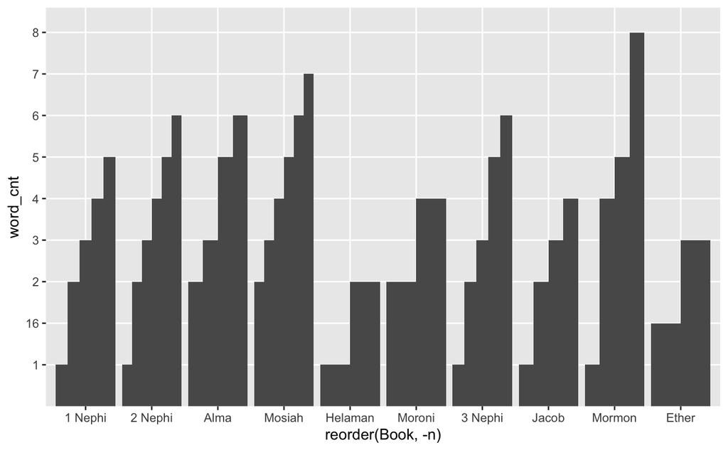

```r
ggplot(data=test, aes(x=reorder(Book, -n), y=word_cnt), fill=Book) +
  geom_bar(position = "dodge", stat="identity")
```